# Calidad del aire Madrid en 2017

Ismael Jiménez

16 de diciembre de 2017

## Introducción

En este estudio se utilizan datos generados por un conjunto de estaciones situadas en diferentes puntos de la ciudad de Madrid.  
La magnitud objeto del estudio es el NO2, un compuesto químico que provoca efectos nocivos en las salud de las personas.

## Fuente de datos

La fuente de datos utilizada en el estudio contiene los valores medios diarios desde enero hasta noviembre del año 2017 para cada una de las 24 estaciones repartidas por la ciudad de Madrid.

## Niveles de NO2 en el centro de Madrid

Para el estudio de los niveles de NO2 en el centro de Madrid se han seleccionado los datos generados por la estación ubicada en la Plaza de España.

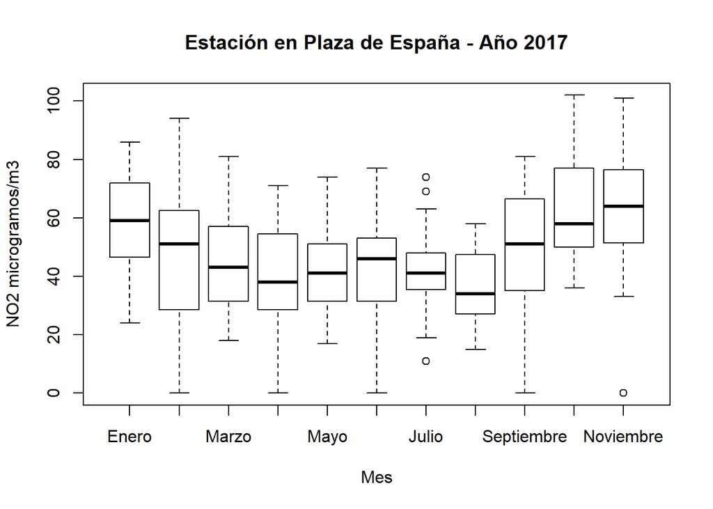

Podemos observar que en los meses de octubre y noviembre se alcanzaron lo valores máximos anuales de 102 y 101 micro gramos por metro cúbico respectivamente, debido principalmente a la falta de precipitaciones.

A continuación vamos a utilizar la función summary provista por R para mostrar la media, mediana,los cuartiles 25 y 75, el máximo y el mínimo de cada mes, que nos va a complementar el gráfico y nos permitirá ver la variación de estas medidas estadísticas a lo largo del año.

```r
summary(plaza_de_espania)
```

```
##      Enero          Febrero          Marzo           Abril
##  Min.   :24.00   Min.   : 0.00   Min.   :18.00   Min.   : 0.00
##  1st Qu.:46.50   1st Qu.:28.50   1st Qu.:31.50   1st Qu.:28.50
##  Median :59.00   Median :51.00   Median :43.00   Median :38.00
##  Mean   :57.23   Mean   :45.97   Mean   :45.45   Mean   :40.61
##  3rd Qu.:72.00   3rd Qu.:62.50   3rd Qu.:57.00   3rd Qu.:54.50
##  Max.   :86.00   Max.   :94.00   Max.   :81.00   Max.   :71.00
##       Mayo           Junio           Julio          Agosto
##  Min.   :17.00   Min.   : 0.00   Min.   :11.0   Min.   :15.0
##  1st Qu.:31.50   1st Qu.:31.50   1st Qu.:35.5   1st Qu.:27.0
##  Median :41.00   Median :46.00   Median :41.0   Median :34.0
##  Mean   :40.48   Mean   :42.87   Mean   :41.9   Mean   :35.9
##  3rd Qu.:51.00   3rd Qu.:53.00   3rd Qu.:48.0   3rd Qu.:47.5
##  Max.   :74.00   Max.   :77.00   Max.   :74.0   Max.   :58.0
##    Septiembre       Octubre         Noviembre
##  Min.   : 0.00   Min.   : 36.00   Min.   :  0.00
##  1st Qu.:35.00   1st Qu.: 50.00   1st Qu.: 51.50
##  Median :51.00   Median : 58.00   Median : 64.00
##  Mean   :50.39   Mean   : 63.68   Mean   : 64.03
##  3rd Qu.:66.50   3rd Qu.: 77.00   3rd Qu.: 76.50
##  Max.   :81.00   Max.   :102.00   Max.   :101.00
```

## Niveles de NO2 en las afueras de Madrid

Ahora vamos a analizar los niveles de NO2 en las afueras de Madrid. Para ello utilizamos los datos generados por la estación ubicada en el Pardo.

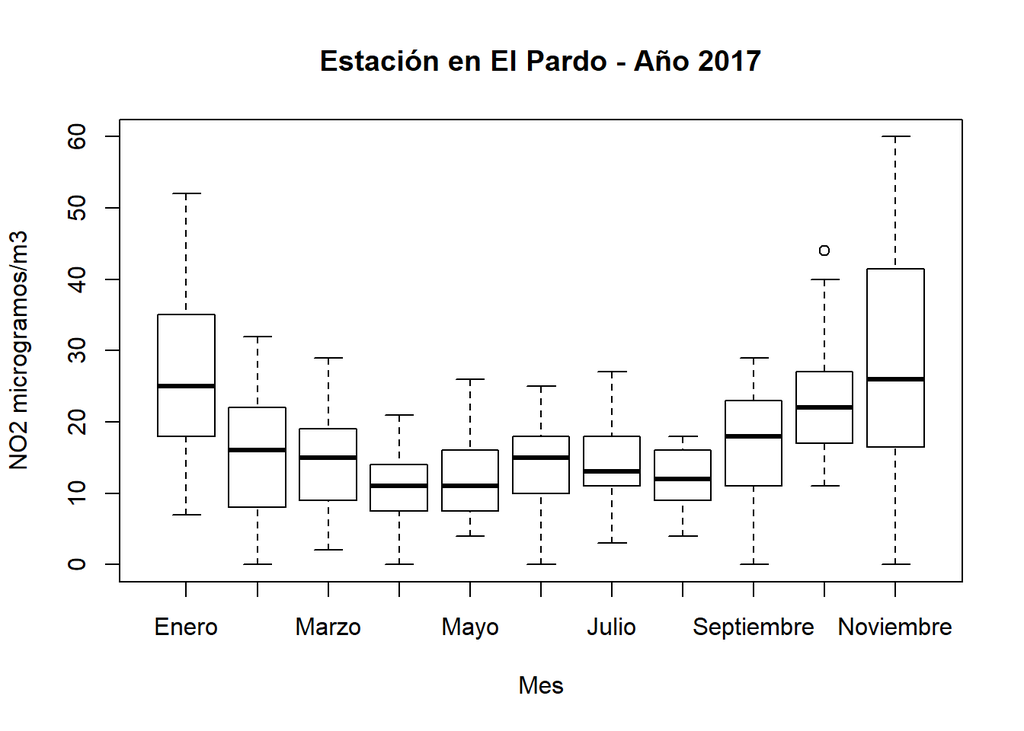

Complementamos el boxplot con los datos estadísticos que nos proporciona la función summary.

```
##      Enero          Febrero          Marzo          Abril
##  Min.   : 7.00   Min.   : 0.00   Min.   : 2.0   Min.   : 0.00
##  1st Qu.:18.00   1st Qu.: 8.00   1st Qu.: 9.0   1st Qu.: 7.50
##  Median :25.00   Median :16.00   Median :15.0   Median :11.00
##  Mean   :27.87   Mean   :15.58   Mean   :15.1   Mean   :10.97
##  3rd Qu.:35.00   3rd Qu.:22.00   3rd Qu.:19.0   3rd Qu.:14.00
##  Max.   :52.00   Max.   :32.00   Max.   :29.0   Max.   :21.00
##       Mayo           Junio           Julio           Agosto
##  Min.   : 4.00   Min.   : 0.00   Min.   : 3.00   Min.   : 4.00
##  1st Qu.: 7.50   1st Qu.:10.00   1st Qu.:11.00   1st Qu.: 9.00
##  Median :11.00   Median :15.00   Median :13.00   Median :12.00
##  Mean   :11.77   Mean   :13.48   Mean   :14.55   Mean   :11.97
##  3rd Qu.:16.00   3rd Qu.:18.00   3rd Qu.:18.00   3rd Qu.:16.00
##  Max.   :26.00   Max.   :25.00   Max.   :27.00   Max.   :18.00
##    Septiembre       Octubre        Noviembre
##  Min.   : 0.00   Min.   :11.00   Min.   : 0.00
##  1st Qu.:11.00   1st Qu.:17.00   1st Qu.:16.50
##  Median :18.00   Median :22.00   Median :26.00
##  Mean   :16.29   Mean   :23.19   Mean   :29.03
##  3rd Qu.:23.00   3rd Qu.:27.00   3rd Qu.:41.50
##  Max.   :29.00   Max.   :44.00   Max.   :60.00
```

En el gráfico podemos observar que Noviembre es el mes con mayor variabilidad y donde se alcanzó el máximo de 60 microgramos/m3, debido principalmente a los meses acumulados sin precipitaciones.  
Comparando los datos estadísticos de las zonas estudiadas observamos una clara mejoría en la calidad del aire en las afueras de Madrid.